# DS400: Assignment I (R)

Mohamed Elsherif (Student ID: 6378374)

2024-11-05

### Directory set up & Libraries Installation

```r
options(repos = c(CRAN = "https://cloud.r-project.org"))
rm(list = ls())
setwd("C:/Users/Admin/Downloads/DS400_WS24-25/Assignment01")
getwd()
```

```
## [1] "C:/Users/Admin/Downloads/DS400_WS24-25/Assignment01"
```

```r
install.packages("ggplot2")
options(warn = -1)
# Load libraries
library(readr)
library(data.table)
library(microbenchmark)
library(ggplot2)
library(lubridate)
library(tidyr)
library(dplyr)
library(stats)
```

# Importing Data

### 1. Reading cvs files using three different functions

```r
# Define file paths
listings <- "./data/listings_muc.csv"
calendar <- "./data/calendar_muc.csv"

# Read the listings data using the 3 different methods
AirBNB_listings_muc_utils <- utils::read.csv(listings)
AirBNB_listings_muc_readr <- readr::read_csv(listings, show_col_types = FALSE)
AirBNB_listings_muc_data_table <- data.table::fread(listings)

# Read the calendar data using the 3 different methods
AirBNB_calendar_muc_utils <- utils::read.csv(calendar)
AirBNB_calendar_muc_readr <- readr::read_csv(calendar, show_col_types = FALSE)
AirBNB_calendar_muc_data_table <- data.table::fread(calendar)
```

### 2. Print the first five rows and column types

```r
# Print the first five rows and column types for listings data
cat("First five rows of listings data (utils):")
```

```
## First five rows of listings data (utils):
```

```r
head(AirBNB_listings_muc_utils, 5)
```

```
##       id                                               name host_id host_name
## 1  97945                   Deluxw-Apartm. with roof terrace  517685  Angelika
## 2 114695                 Apartment Munich/East with sundeck  581737   Stephan
## 3 127383                  City apartment next to Pinakothek  630556     Sonja
## 4 159634 Fancy, bright central roof top flat and homeoffice  765694    Susana
## 5 170154              Own floor & bath, parking & breakfast  108297      Alex
##   neighbourhood_group      neighbourhood latitude longitude       room_type
## 1                  NA             Hadern 48.11492  11.48954 Entire home/apt
## 2                  NA       Berg am Laim 48.12071  11.63758 Entire home/apt
## 3                  NA        Maxvorstadt 48.15199  11.56482 Entire home/apt
## 4                  NA Pasing-Obermenzing 48.13855  11.46586 Entire home/apt
## 5                  NA  Sendling-Westpark 48.10814  11.52733    Private room
##   number_of_reviews last_review reviews_per_month
## 1               127  2019-10-03              0.82
## 2                69  2024-06-22              0.44
## 3               112  2024-02-04              0.70
## 4                40  2024-05-28              0.26
## 5               559  2024-06-21              3.60
##   calculated_host_listings_count availability_365 number_of_reviews_ltm license
## 1                              2              200                     0    <NA>
## 2                              3              108                    12    <NA>
## 3                              1                0                     5    <NA>
## 4                              1               12                     4    <NA>
## 5                              1              123                    27    <NA>
```

```r
cat("Column types of listings data (utils):")
```

```
## Column types of listings data (utils):
```

```r
str(AirBNB_listings_muc_utils)
```

```
## 'data.frame':    6746 obs. of  16 variables:
##  $ id                            : num  97945 114695 127383 159634 170154 ...
##  $ name                          : chr  "Deluxw-Apartm. with roof terrace" "Apartment Munich/East with sundeck" "City apartment next to Pinakothek" "Fancy, bright central roof top flat and homeoffice" ...
##  $ host_id                       : int  517685 581737 630556 765694 108297 814793 823913 825767 880705 910486 ...
##  $ host_name                     : chr  "Angelika" "Stephan" "Sonja" "Susana" ...
##  $ neighbourhood_group           : logi  NA NA NA NA NA NA ...
##  $ neighbourhood                 : chr  "Hadern" "Berg am Laim" "Maxvorstadt" "Pasing-Obermenzing" ...
##  $ latitude                      : num  48.1 48.1 48.2 48.1 48.1 ...
##  $ longitude                     : num  11.5 11.6 11.6 11.5 11.5 ...
##  $ room_type                     : chr  "Entire home/apt" "Entire home/apt" "Entire home/apt" "Entire home/apt" ...
##  $ number_of_reviews             : int  127 69 112 40 559 63 223 105 1 162 ...
##  $ last_review                   : chr  "2019-10-03" "2024-06-22" "2024-02-04" "2024-05-28" ...
##  $ reviews_per_month             : num  0.82 0.44 0.7 0.26 3.6 0.4 1.81 0.71 0.05 1.09 ...
##  $ calculated_host_listings_count: int  2 3 1 1 1 1 2 1 1 1 ...
##  $ availability_365              : int  200 108 0 12 123 0 0 86 361 1 ...
##  $ number_of_reviews_ltm         : int  0 12 5 4 27 0 0 11 0 0 ...
##  $ license                       : chr  NA NA NA NA ...
```

```r
# Print the first five rows and column types for calendar data
cat("First five rows of calendar data (utils):")
```

```
## First five rows of calendar data (utils):
```

```r
head(AirBNB_calendar_muc_utils, 5)
```

```
##   listing_id       date available  price adjusted_price min_max_nights
## 1      97945 2024-06-27     FALSE $95.00             NA           2-90
## 2      97945 2024-06-28     FALSE $95.00             NA           2-90
## 3      97945 2024-06-29     FALSE $95.00             NA           2-90
## 4      97945 2024-06-30     FALSE $95.00             NA           2-90
## 5      97945 2024-07-01     FALSE $95.00             NA           2-90
```

```r
cat("Column types of calendar data (utils):")
```

```
## Column types of calendar data (utils):
```

```r
print(sapply(AirBNB_calendar_muc_utils, class))
```

```
##     listing_id           date      available          price adjusted_price
##      "numeric"    "character"      "logical"    "character"      "logical"
## min_max_nights
##    "character"
```

# Profiling the Import

### 3. Computation time of read.csv, read_csv and fread

```r
mbm <- microbenchmark(
  listings_utils = read.csv(listings),
  listings_readr = read_csv(listings, show_col_types = FALSE),
  listings_fread = fread(listings),
  times = 10
)
print(mbm)
```

```
## Unit: milliseconds
##            expr     min      lq     mean   median      uq      max neval
##  listings_utils 65.4266 70.4470 82.30631 73.43175 89.6898 131.7379    10
##  listings_readr 39.0682 40.7915 42.73602 41.46710 44.1906  52.4758    10
##  listings_fread 11.9578 12.9021 15.03469 14.16335 16.4107  20.8591    10
```

compare the three functions

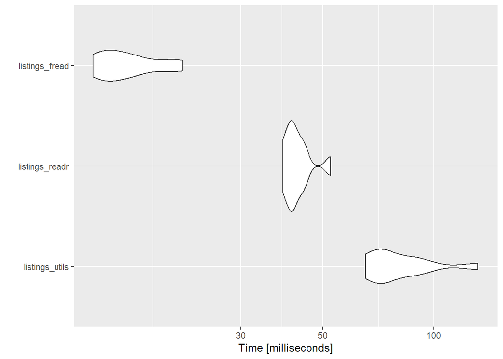

```r
autoplot(mbm)
```

**comment**

- **fread** is the fastest and **read.csv** is the slowest. By comparing the mean time for both functions, we see that fread is appr. 5 times faster than the read.csv function.

# Tidying the data

### 4. Requirements for Tidy data:

- Each variable forms a column.
- Each observation forms a row.
- Each type of observational unit forms a table.

### 5. Evaluating Tidiness of listings and calendar tables:

#### I- listings_muc.csv

**listings_muc.csv is arguably NOT tidy for the following reasons:**

- **Main Reason** The ‘host_id’ and ‘host_name’ columns form a different type of observational unit and are categorical variables that won’t change, Therefore we can create a separate table to store this information. This task wasn’t explicitly mentioned in the assignment, so I didn’t include it as part of my solution below.
- The enitre ‘neighbourhood_group’ column and major portion of ‘license’ column have missing values, which questions the purpose of having both variables included for analysis. To rectify this, we should remove both.
- Missing values in columns ‘last_review’ and its current values are stored as an object datatype, requiring conversion to datetime for analysis. However since dates of ‘last_review’ offers limited value in current analysis unless feature engineered (e.g., into “days since last review”), I opted to drop it from the dataset.
- Missing values in column ‘reviews_per_month’ columns when ‘number_of_reviews’ has value of 0. To rectify this, we can replace those missing values with 0.
- The column ‘id’ needs to be converted from float in to integer or object (to avoid issues with decimals). In R, no need to perform such step as R will automatically remove the ‘.0’.
- The columns ‘name’ and ‘host_name’ (which has 1 missing value) seem irrelevant to analysis and can be removed.

```r
# Drop the 'name', 'host_name', 'neighbourhood_group', 'last_review' and 'license' columns
AirBNB_listings_muc_readr<- AirBNB_listings_muc_readr %>%
  select(-name, -host_name, -neighbourhood_group, -last_review, -license)

# Set 'reviews_per_month' to 0 where 'number_of_reviews' is 0
AirBNB_listings_muc_readr <- AirBNB_listings_muc_readr %>%
  mutate(reviews_per_month = ifelse(number_of_reviews == 0, 0, reviews_per_month))
```

#### II- calendar_muc.csv

**calendar_muc.csv is NOT tidy because:**

- The ‘min_max_nights’ information are two different variables placed in one column, and each cell has two values. To rectify this, we should separate into two columns: ‘minimum_nights’ and ‘maximum_nights’.
- The columns ‘price’ and ‘date’ need to be converted to float/numeric (after removing the ‘$’ sign) and datetime format respectively.
- The column ‘listing_id’ need to be converted to integer or object (to avoid issues with decimals). In R, no need to perform such step as R will automatically remove the ‘.0’.
- The enitre ‘adjusted_price’ column has missing values, which questions the purpose of having this variable included for analysis. To rectify this, we should remove it.

```r
# Split 'min_max_nights' into 'minimum_nights' and 'maximum_nights'
AirBNB_calendar_muc_readr <- AirBNB_calendar_muc_readr %>%
  separate(min_max_nights, into = c("minimum_nights", "maximum_nights"), sep = "-", convert = TRUE)

# Remove the dollar sign and any commas (if present)
AirBNB_calendar_muc_readr$price <- gsub("[^0-9.]", "", AirBNB_calendar_muc_readr$price)

# Convert the cleaned 'price' column from character to numeric
AirBNB_calendar_muc_readr$price <- as.numeric(AirBNB_calendar_muc_readr$price)

# Drop the 'adjusted_price' column from the data frame
AirBNB_calendar_muc_readr <- AirBNB_calendar_muc_readr %>%
  select(-adjusted_price)
```

### 6. Shape of the tables after making the data tidy

```r
# Print the first five rows and column types for listings data
cat("First five rows of listings data (utils): \n")
```

```
## First five rows of listings data (utils):
```

```r
head(AirBNB_listings_muc_readr, 5)
```

```
## # A tibble: 5 × 11
##       id host_id neighbourhood    latitude longitude room_type number_of_reviews
##    <dbl>   <dbl> <chr>               <dbl>     <dbl> <chr>                 <dbl>
## 1  97945  517685 Hadern               48.1      11.5 Entire h…               127
## 2 114695  581737 Berg am Laim         48.1      11.6 Entire h…                69
## 3 127383  630556 Maxvorstadt          48.2      11.6 Entire h…               112
## 4 159634  765694 Pasing-Obermenz…     48.1      11.5 Entire h…                40
## 5 170154  108297 Sendling-Westpa…     48.1      11.5 Private …               559
## # ℹ 4 more variables: reviews_per_month <dbl>,
## #   calculated_host_listings_count <dbl>, availability_365 <dbl>,
## #   number_of_reviews_ltm <dbl>
```

```r
cat("Shape of listings data (utils):")
```

```
## Shape of listings data (utils):
```

```r
print(dim(AirBNB_listings_muc_readr))
```

```
## [1] 6746   11
```

```r
cat("Column types of listings data (utils):")
```

```
## Column types of listings data (utils):
```

```r
str(AirBNB_listings_muc_readr)
```

```
## tibble [6,746 × 11] (S3: tbl_df/tbl/data.frame)
##  $ id                            : num [1:6746] 97945 114695 127383 159634 170154 ...
##  $ host_id                       : num [1:6746] 517685 581737 630556 765694 108297 ...
##  $ neighbourhood                 : chr [1:6746] "Hadern" "Berg am Laim" "Maxvorstadt" "Pasing-Obermenzing" ...
##  $ latitude                      : num [1:6746] 48.1 48.1 48.2 48.1 48.1 ...
##  $ longitude                     : num [1:6746] 11.5 11.6 11.6 11.5 11.5 ...
##  $ room_type                     : chr [1:6746] "Entire home/apt" "Entire home/apt" "Entire home/apt" "Entire home/apt" ...
##  $ number_of_reviews             : num [1:6746] 127 69 112 40 559 63 223 105 1 162 ...
##  $ reviews_per_month             : num [1:6746] 0.82 0.44 0.7 0.26 3.6 0.4 1.81 0.71 0.05 1.09 ...
##  $ calculated_host_listings_count: num [1:6746] 2 3 1 1 1 1 2 1 1 1 ...
##  $ availability_365              : num [1:6746] 200 108 0 12 123 0 0 86 361 1 ...
##  $ number_of_reviews_ltm         : num [1:6746] 0 12 5 4 27 0 0 11 0 0 ...
```

```r
# Print the first five rows and column types for calendar data
cat("First five rows of calendar data (utils): \n")
```

```
## First five rows of calendar data (utils):
```

```r
head(AirBNB_calendar_muc_readr, 5)
```

```
## # A tibble: 5 × 6
##   listing_id date       available price minimum_nights maximum_nights
##        <dbl> <date>     <lgl>     <dbl>          <int>          <int>
## 1      97945 2024-06-27 FALSE        95              2             90
## 2      97945 2024-06-28 FALSE        95              2             90
## 3      97945 2024-06-29 FALSE        95              2             90
## 4      97945 2024-06-30 FALSE        95              2             90
## 5      97945 2024-07-01 FALSE        95              2             90
```

```r
cat("Shape of calendar data (utils):")
```

```
## Shape of calendar data (utils):
```

```r
print(dim(AirBNB_calendar_muc_readr))
```

```
## [1] 2462238       6
```

```r
cat("Column types of calendar data (utils):")
```

```
## Column types of calendar data (utils):
```

```r
str(AirBNB_calendar_muc_readr)
```

```
## tibble [2,462,238 × 6] (S3: tbl_df/tbl/data.frame)
##  $ listing_id    : num [1:2462238] 97945 97945 97945 97945 97945 ...
##  $ date          : Date[1:2462238], format: "2024-06-27" "2024-06-28" ...
##  $ available     : logi [1:2462238] FALSE FALSE FALSE FALSE FALSE FALSE ...
##  $ price         : num [1:2462238] 95 95 95 95 95 95 95 95 95 95 ...
##  $ minimum_nights: int [1:2462238] 2 2 2 2 2 2 2 2 2 2 ...
##  $ maximum_nights: int [1:2462238] 90 90 90 90 90 90 90 90 90 90 ...
```

### 7. Change the name of the listing_id column to id

```r
# Rename 'listing_id' to 'id' in the AirBNB_calendar_muc_readr_cleaned data frame
AirBNB_calendar_muc_readr <- AirBNB_calendar_muc_readr %>%
  dplyr::rename(id = listing_id)
#names(AirBNB_calendar_muc_readr)[names(AirBNB_calendar_muc_readr) == "listing_id"] <- "id"
```

### 8. Aggregate the calendar data to the listing level

```r
# Aggregate the calendar data on 'id'
AirBNB_calendar_aggregated <- AirBNB_calendar_muc_readr %>%
  dplyr::group_by(id) %>%
  dplyr::summarize(
    minimum_nights = max(minimum_nights, na.rm = TRUE),
    maximum_nights = min(maximum_nights, na.rm = TRUE),    #
    price = max(price),
    available = sum(available == TRUE),     # Get maximum price (in case there are variations)
    .groups = "drop"                                       # Drop the grouping
  )
```

### 9. Merge the aggregated calendar and the listings data by id. Call the resulting data frame merged and print its shape.

```r
# Merge with the listings dataset
merged <- AirBNB_listings_muc_readr %>%
  left_join(AirBNB_calendar_aggregated, by = "id")

cat("Shape of merged data:", dim(merged), "\n")
```

```
## Shape of merged data: 6746 15
```

```r
head(merged, 5)
```

```
## # A tibble: 5 × 15
##       id host_id neighbourhood    latitude longitude room_type number_of_reviews
##    <dbl>   <dbl> <chr>               <dbl>     <dbl> <chr>                 <dbl>
## 1  97945  517685 Hadern               48.1      11.5 Entire h…               127
## 2 114695  581737 Berg am Laim         48.1      11.6 Entire h…                69
## 3 127383  630556 Maxvorstadt          48.2      11.6 Entire h…               112
## 4 159634  765694 Pasing-Obermenz…     48.1      11.5 Entire h…                40
## 5 170154  108297 Sendling-Westpa…     48.1      11.5 Private …               559
## # ℹ 8 more variables: reviews_per_month <dbl>,
## #   calculated_host_listings_count <dbl>, availability_365 <dbl>,
## #   number_of_reviews_ltm <dbl>, minimum_nights <int>, maximum_nights <int>,
## #   price <dbl>, available <int>
```

### 10. How many neighborhoods are there in Munich? Print the number of neighborhoods and all their names. How many and which room types are there?

```r
# Count the number of unique neighborhoods in the merged dataset
neighborhoods <- unique(merged$neighbourhood)

# Get the number of neighborhoods
num_neighborhoods <- length(neighborhoods)

# Print the number of neighborhoods and their names
cat("Number of neighborhoods in Munich:", num_neighborhoods, "\n")
```

```
## Number of neighborhoods in Munich: 25
```

```r
cat("Neighborhoods:\n")
```

```
## Neighborhoods:
```

```r
print(neighborhoods)
```

```
##  [1] "Hadern"
##  [2] "Berg am Laim"
##  [3] "Maxvorstadt"
##  [4] "Pasing-Obermenzing"
##  [5] "Sendling-Westpark"
##  [6] "Neuhausen-Nymphenburg"
##  [7] "Schwabing-West"
##  [8] "Allach-Untermenzing"
##  [9] "Au-Haidhausen"
## [10] "Schwanthalerhöhe"
## [11] "Bogenhausen"
## [12] "Ludwigsvorstadt-Isarvorstadt"
## [13] "Sendling"
## [14] "Ramersdorf-Perlach"
## [15] "Thalkirchen-Obersendling-Forstenried-Fürstenried-Solln"
## [16] "Untergiesing-Harlaching"
## [17] "Obergiesing"
## [18] "Schwabing-Freimann"
## [19] "Tudering-Riem"
## [20] "Feldmoching-Hasenbergl"
## [21] "Milbertshofen-Am Hart"
## [22] "Altstadt-Lehel"
## [23] "Laim"
## [24] "Moosach"
## [25] "Aubing-Lochhausen-Langwied"
```

```r
# Count the number of unique room types in the merged dataset
room_types <- unique(merged$room_type)

# Get the number of room types
num_room_types <- length(room_types)

# Print the number of room types and their names
cat("Number of room types:", num_room_types, "\n")
```

```
## Number of room types: 4
```

```r
cat("Room Types:\n")
```

```
## Room Types:
```

```r
print(room_types)
```

```
## [1] "Entire home/apt" "Private room"    "Shared room"     "Hotel room"
```

### 11. Regress the number of available days on the price and the minimum_nights.

```r
# Fit the regression model
model <- lm(available ~ price + minimum_nights, data = merged)
summary(model)
```

```
##
## Call:
## lm(formula = available ~ price + minimum_nights, data = merged)
##
## Residuals:
##     Min      1Q  Median      3Q     Max
## -380.81 -106.83  -42.46   90.10  258.30
##
## Coefficients:
##                 Estimate Std. Error t value Pr(>|t|)
## (Intercept)    1.063e+02  1.504e+00  70.672  < 2e-16 ***
## price          3.847e-03  1.176e-03   3.270  0.00108 **
## minimum_nights 2.747e-01  4.424e-02   6.209 5.66e-10 ***
## ---
## Signif. codes:  0 '***' 0.001 '**' 0.01 '*' 0.05 '.' 0.1 ' ' 1
##
## Residual standard error: 117.5 on 6743 degrees of freedom
## Multiple R-squared:  0.007276,   Adjusted R-squared:  0.006982
## F-statistic: 24.71 on 2 and 6743 DF,  p-value: 2.027e-11
```

### 12. Regress the number of available days on the price and the minimum_nights, but include neighborhood and room type as fixed effects.

```r
# Convert neighbourhood and room_type to factors if they are not already
merged$neighbourhood <- as.factor(merged$neighbourhood)
merged$room_type <- as.factor(merged$room_type)

# Fit the regression model with fixed effects for neighborhood and room type
model_fixed_effects <- lm(available ~ price + minimum_nights + neighbourhood + room_type, data = merged)
summary(model_fixed_effects)
```

```
##
## Call:
## lm(formula = available ~ price + minimum_nights + neighbourhood +
##     room_type, data = merged)
##
## Residuals:
##     Min      1Q  Median      3Q     Max
## -427.69  -95.52  -43.54   88.04  290.07
##
## Coefficients:
##                                                                       Estimate
## (Intercept)                                                         134.371903
## price                                                                 0.004349
## minimum_nights                                                        0.303321
## neighbourhoodAltstadt-Lehel                                         -37.182435
## neighbourhoodAu-Haidhausen                                          -62.254098
## neighbourhoodAubing-Lochhausen-Langwied                             -23.471586
## neighbourhoodBerg am Laim                                           -19.620067
## neighbourhoodBogenhausen                                            -40.129717
## neighbourhoodFeldmoching-Hasenbergl                                   5.402249
## neighbourhoodHadern                                                 -60.025204
## neighbourhoodLaim                                                   -28.442285
## neighbourhoodLudwigsvorstadt-Isarvorstadt                           -33.274772
## neighbourhoodMaxvorstadt                                            -46.155712
## neighbourhoodMilbertshofen-Am Hart                                  -48.715777
## neighbourhoodMoosach                                                -19.306277
## neighbourhoodNeuhausen-Nymphenburg                                  -37.592691
## neighbourhoodObergiesing                                            -40.330725
## neighbourhoodPasing-Obermenzing                                     -30.782247
## neighbourhoodRamersdorf-Perlach                                     -25.804912
## neighbourhoodSchwabing-Freimann                                     -39.198613
## neighbourhoodSchwabing-West                                         -49.472911
## neighbourhoodSchwanthalerhöhe                                       -38.734914
## neighbourhoodSendling                                               -57.401803
## neighbourhoodSendling-Westpark                                      -40.855912
## neighbourhoodThalkirchen-Obersendling-Forstenried-Fürstenried-Solln  -4.057202
## neighbourhoodTudering-Riem                                           -7.916930
## neighbourhoodUntergiesing-Harlaching                                -32.558584
## room_typeHotel room                                                 118.926349
## room_typePrivate room                                                22.706391
```

[output cut: 116 more lines]

```
## neighbourhoodSchwanthalerhöhe                                       *
## neighbourhoodSendling                                               ***
## neighbourhoodSendling-Westpark                                      *
## neighbourhoodThalkirchen-Obersendling-Forstenried-Fürstenried-Solln
## neighbourhoodTudering-Riem
## neighbourhoodUntergiesing-Harlaching                                .
## room_typeHotel room                                                 ***
## room_typePrivate room                                               ***
## room_typeShared room
## ---
## Signif. codes:  0 '***' 0.001 '**' 0.01 '*' 0.05 '.' 0.1 ' ' 1
##
## Residual standard error: 115.9 on 6716 degrees of freedom
## Multiple R-squared:  0.03669,    Adjusted R-squared:  0.03253
## F-statistic: 8.821 on 29 and 6716 DF,  p-value: < 2.2e-16
```

| **END OF SOLUTION** |
| --- |